# Assignment 1

2024-12-07

# Part 1

## 5.

We simulate the data. We simulate $10^5$ data points form the multivariate normal distribution with mean $\begin{pmatrix} 0 \\ 0 \\ 0 \end{pmatrix}$ and variance $\begin{pmatrix} 1 & 0.25 & 0.5 \\ 0.25 & 1 & 0.5 \\ 0.5 & 0.5 & 1 \end{pmatrix}$.

```r
set.seed(7878)
n <- 10^5
sigma <- matrix(c(1, 0.25, 0.5, 0.25, 1, 0.5, 0.5, 0.5, 1), nrow = 3)
X <- mvrnorm(n, c(0,0, 0), sigma)
```

We will illustrate that the conditional distribution of $\begin{pmatrix} X_1 \\ X_2 \end{pmatrix} \vert X_3 = x_3$ is as expected by conditioning on $|X_3| = 0$. To approximate this ($X_3$ has a continuous distribution), we find the rows of $X$ for which $|X_3| \leq 0.05$:

```r
cond <- which(abs(X[,3]) < 0.05)
```

We calculate the correlation of $X_1$ and $X_2$ for those $X_1$ and $X_2$ for which $|X_3| \leq 0.05$.

```r
cor(X[cond,1], X[cond,2])
```

```
## [1] 0.001381612
```

Which is as expected close to $0$. This is different from the correlation of $X_1$ and $X_2$ in general, which is by construction $\approx 0.25$:

```r
cor(X[,1], X[,2])
```

```
## [1] 0.2495407
```

To visualize the conditional distribution of $X_1$ and $X_2$ we create the two scatterplot below. In the unconditional distribution the two variables are positively correlated, while they in the conditional distribution are uncorrelated, and thus (since they are normal) independent.

[figure not shown]

As a last illustration, we have made histograms of the marginal distributions of the two random variables, conditional on $X_3 = 0$ and unconditionally. The marginal distribution of both variables unconditionally is $\mathcal{N}(0,1)$ and conditionally on $X_3 = 0$, it is, with use of our calculations from the previous exercises, $\mathcal{N}(0, 0.75)$.

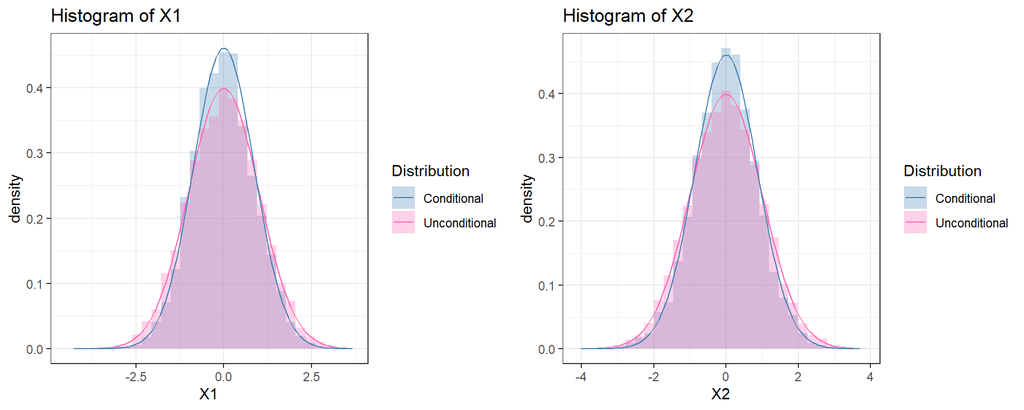

Notice also how the variance reduces as we condition, this is also to be expected as we gain further information.

In example 2.5 we showed that the variance matrix of the conditional distribution does not depend on the value of the conditioning variable. Having thus showed that the $ X_1 X_3 = 0$ and $ X_2 X_3 = 0$ are independent and with the expected variance, this will also be true for all other values of $X_3$. (*er det rigtigt???*)

All in all the conditional distribution of $\begin{pmatrix} X_1 \\ X_2 \end{pmatrix} \vert X_3$ behaves very much as expected.

# Part 2

```r
load("assignment2024-1.Rdata")
```

Data plots:

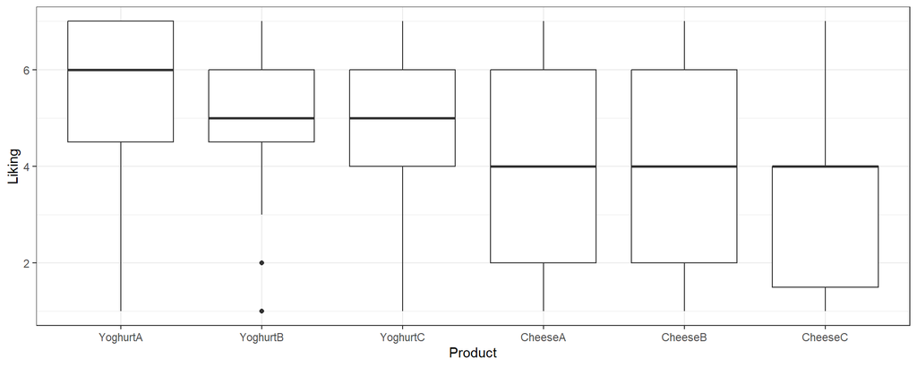

Model fits:

```r
fit1 <- lmer(Liking ~ Product + (1|Participant) + (1|Class), data=likingdata)
fit2 <- lmer(Liking ~ ProdVersion + ProdType + (1|Participant) + (1|Class), data=likingdata)
```

## 1.

The statistical model from fit1, can be described as:

$$Y_{ijk} = \beta_{i} + B_{j}^{\text{par}}
+ B_{k}^{\text{class}} + \epsilon_{ijk}$$

Where we use triple indexing. $i=1,\ldots, 6$ corresponds to the $6$ different products, $j=1,\ldots,75$ corresponds to the $75$ different participants, $k=1,\ldots,5$ corresponds to the $5$ different classes.

Where $B^{\text{par}} \sim \mathcal{N}_{75}(0, \tau_{\text{par}}^2 I_{75})$, $B^{\text{class}} \sim \mathcal{N}_{5}(0, \tau_{\text{class}}^2 I_{5})$ and $\epsilon \sim \mathcal{N}_{450}(0, \sigma^2 I_{450})$ are all independent.

Participant and class are considered random effects, since we are not interested in the specific participants or classes as such, but rather as representatives of the population of children and classes.

Product is included as a fixed effect since we are interested in investigating the child friendliness of the different products.

## 3.

The factor `Product` is the interaction of the two factors `ProdVersion` and `ProdType`, therefore the subspace spanned by `ProdVersion` and `ProdType` is included in the subspace spanned by `Product`, and fit2 is thus a submodel of fit1. In other words if we know the `Product` we also know the `ProdVersion` and `ProdType`.

In fit1 we estimate $6$ different fixed effects parameters, 1 intercept parameter, and then $5$ additional parameters for each additional interaction level between `ProdVersion` and `ProdType`. In fit2 we estimate $4$ fixed effect parameters, $1$ intercept parameter, $2$ for each additional `ProdVersion` level and $1$ for the last level of `ProdType`. We assume no interaction effects between the two factors `ProdVersion` and `ProdType` in fit2.

Letting $L_0$ denote the subspace of $\RR^n$ spanned by the model matrix from fit2 and $L_X$ denote the subspace of $\RR^n$ spanned by the model matrix from fit1, we can test the hypothesis of $EY \in L_0 \subseteq L_X$ with the likelihood ratio statistic. The test relies on asymptotic results which we use without further arguments. We perform the test by use of the anova command:

```r
anova(fit1,fit2)
```

```
## refitting model(s) with ML (instead of REML)
```

```
## Data: likingdata
## Models:
## fit2: Liking ~ ProdVersion + ProdType + (1 | Participant) + (1 | Class)
## fit1: Liking ~ Product + (1 | Participant) + (1 | Class)
##      npar    AIC    BIC  logLik deviance  Chisq Df Pr(>Chisq)
## fit2    7 1777.8 1806.6 -881.91   1763.8
## fit1    9 1781.1 1818.1 -881.56   1763.1 0.7031  2     0.7036
```

With a significance level of 0.05 we can most certainly not reject the null hypothesis, and we can conclude that the interaction factor `product` does not improve the model fit significantly.

*Jeg tænker at siden at p-værdien er så høj at vi ikke gider at simulere?*

```r
## Simulated p-value in test for TVset
#sim12 <- pbkrtest::PBmodcomp(fit1, fit2, nsim=2000, seed=967)
#
## Extract simulated LRTs
#LRT_12 <- as.numeric(sim12$ref)
#
## Density for chi-square with df=1
#dchisq2 <- function(x) dchisq(x,df=2)
#
## Histogram with overlaid density
#data.frame(LRT_12 = LRT_12) |>
#  ggplot(aes(x = LRT_12)) +
#  geom_histogram(aes(y = ..density..), breaks=seq(0,18,0.5), color="black", fill="white") +
#  geom_function(fun = dchisq2, colour = "red", xlim=c(0.12,15), linewidth=1) +
#  xlab("LRT") + ylab("Density") + ggtitle("Test for ProdVersion effect") +
#  geom_vline(xintercept=0.7031, color="blue",linewidth=1, linetype="dashed")
```

```r
#ggplot()+
#  geom_histogram(aes(x = (1 - pchisq(LRT_12, df = 2)), y = ..density..))+
#  geom_hline(yintercept = 1)
```

## 4.

## 5.

## 6.

### Simulating from the t-distribution

The mean of the $t$-distribution is already $0$. The variance of the $t$-distribution with $\nu$ degrees of freedom is $\frac{\nu}{\nu-2} = \frac{3}{3-2} = 3$. In order to achieve a variance of $\sigma^2$ we would therefore need to scale $X \sim t(3)$ with
$$\sigma^2= V(c \cdot X) = c^2 3 \Leftrightarrow c
= {\frac{\sigma}{\sqrt3}}$$
We define the scaling factors

```r
tauP <- 1; tauC <- 1; sigma <- 1
c_par <- tauP / sqrt(3)
c_class <- tauC / sqrt(3)
c_eps <- sigma / sqrt(3)
```

```r
M <- 2000
n_eps <- nrow(likingdata)
n_par <- unique(likingdata$Participant) |> length()
n_class <- unique(likingdata$Class) |> length()

X <- fit2 |> model.matrix()
Z <- getME(fit2, "Z")
beta <- (summary(fit2) |> coef())[,1]
tauP <- data.frame(VarCorr(fit2))[1,5]
tauC <- data.frame(VarCorr(fit2))[2,5]
sigma <- data.frame(VarCorr(fit2))[3,5]
deltasim2 <- matrix(NA,M,3)

for (i in 1:M){
  B1 <- rt(n = n_par, df = 3) * c_par
  B2 <- rt(n = n_class, df = 3) * c_class
  eps <- rt(n = n_eps, df = 3) * c_eps
  B <- c(B1,B2)
  y <- X %*% beta + Z %*% B + eps
  y <- y |> as.numeric() # NB. This seems to be necessary
  lmm2 <- lmer(y ~ ProdVersion + ProdType + (1|Participant) + (1|Class), data=likingdata)
  deltasim2[i,1] <- fixef(lmm2)[4]
  deltasim2[i,2:3] <- (lmm2 |> confint(method="Wald"))[7,]
}

deltasim2 <- deltasim2 |> data.frame()
names(deltasim2) <- c("est","lower","upper")
```

We calculate the bias:

```r
mean(deltasim2$est - fixef(fit2)[4]) |> knitr::kable(col.names = " ")
```

| -0.000313 |
| --- |

And the coverage:

```r
mean(deltasim2$lower <= fixef(fit2)[4] & fixef(fit2)[4] <= deltasim2$upper) |> knitr::kable(col.names = " ")
```

| 0.9465 |
| --- |

The estimates are still practically unbiased and the confidence intervals achieve accurate coverage.

### Simulating from the exponential distribution

The mean of an exponentially distributed random variable $X$ with rate equal to $1$, is $E(X) = 1$. And the variance of an is $ = 1 $. In order to achieve a mean of $0$ and a variance of $\sigma^2$ we would therefore need to shift and scale $X \sim exp(1)$ with

$$\sigma^2= V(c \cdot X - k) =
c^2 \Leftrightarrow c = \sigma$$
and

$$0 = E(\sigma X - k) = \sigma - k
\Leftrightarrow k = \sigma$$

We define the shift and scaling constants

```r
c_par <- tauP
c_class <- tauC
c_eps <- sigma
```

```r
deltasim3 <- matrix(NA,M,3)

for (i in 1:M){
  B1 <- rexp(n = n_par, rate = 1) * c_par - c_par
  B2 <- rexp(n = n_class, rate = 1) * c_class -  c_class
  eps <- rexp(n = n_eps, rate = 1) * c_eps - c_eps
  B <- c(B1,B2)
  y <- X %*% beta + Z %*% B + eps
  y <- y |> as.numeric() # NB. This seems to be necessary
  lmm2 <- lmer(y ~ ProdVersion + ProdType + (1|Participant) + (1|Class), data=likingdata)
  deltasim3[i,1] <- fixef(lmm2)[4]
  deltasim3[i,2:3] <- (lmm2 |> confint(method="Wald"))[7,]
}

deltasim3 <- deltasim3 |> data.frame()
names(deltasim3) <- c("est","lower","upper")
```

We calculate the bias:

```r
mean(deltasim3$est - fixef(fit2)[4]) |> knitr::kable(col.names = " ")
```

| -0.005931 |
| --- |

And the coverage:

```r
mean(deltasim3$lower <= fixef(fit2)[4] & fixef(fit2)[4] <= deltasim3$upper) |> knitr::kable(col.names = " ")
```

| 0.9505 |
| --- |

The estimates are still almost unbiased and the confidence achieve accurate coverage. We can conclude that the model estimates and confidence intervals are not too sensitive to the type of distribution as long as the mean and variance is correctly specified.

*plot evt. histogrammer*

## 7.

We first examine the residuals. We do this by plotting the fitted values at level one against the residuals.

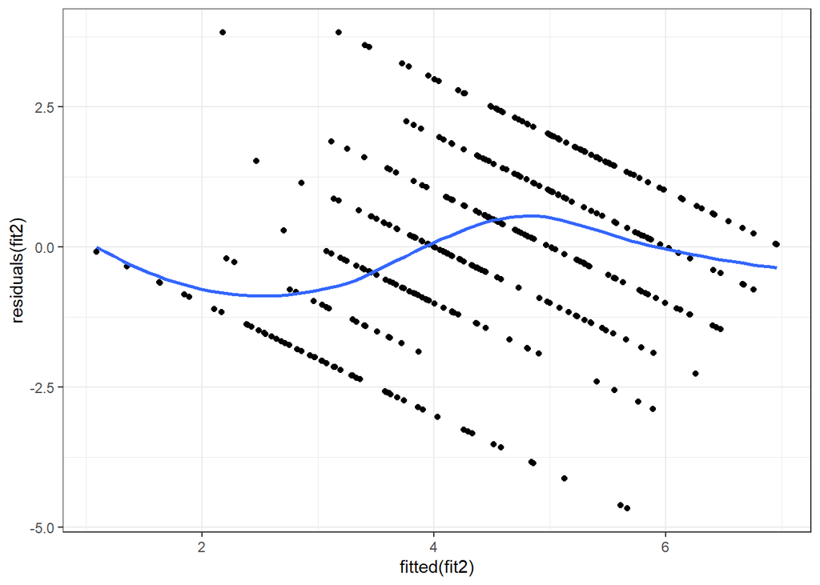

```r
ggplot(data = data.frame(fitted(fit2)), aes(x = fitted(fit2), y = residuals(fit2)))+
  geom_point()+
  geom_smooth(se = FALSE)
```

QQ-plot:

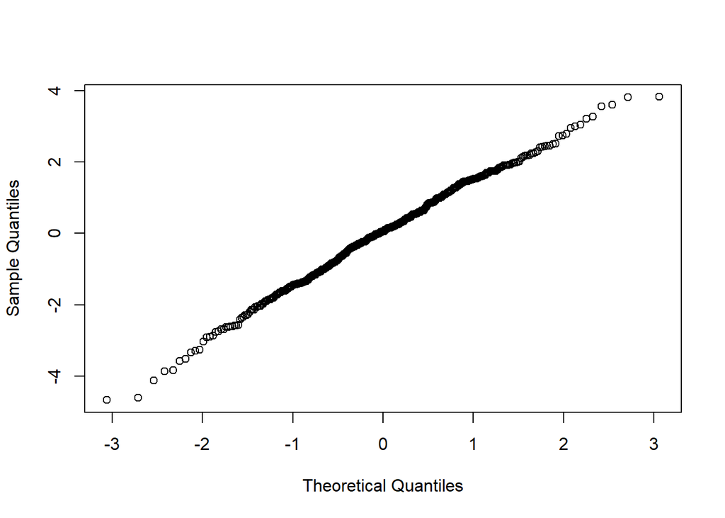

```r
fit2 |> resid() |> qqnorm(main="")
```

Looks good. We now turn to inspect the predicted random effects. They look OK.

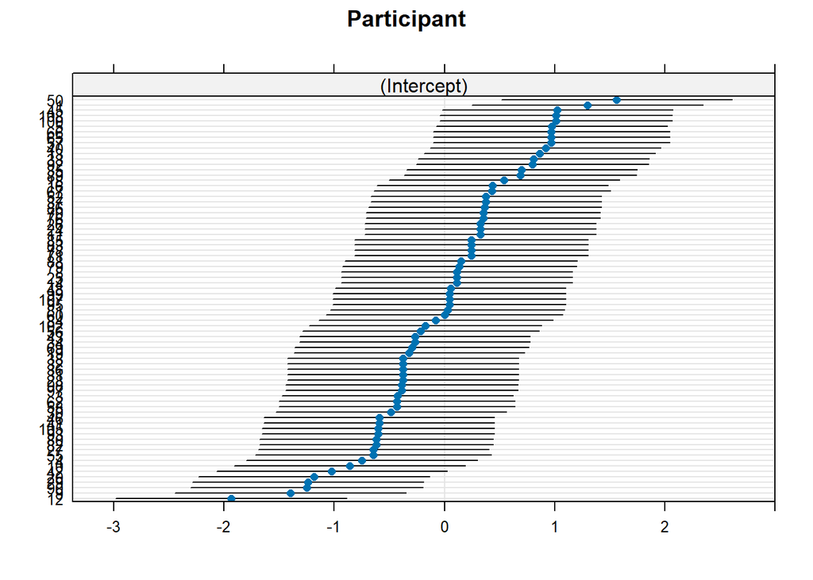

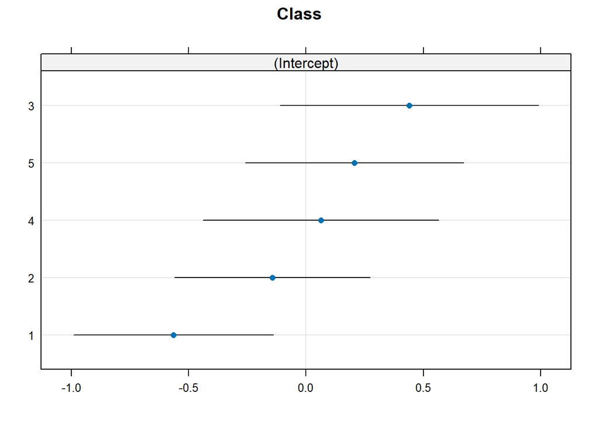

```r
library(lattice)
fit2 |> ranef() |> dotplot()
```

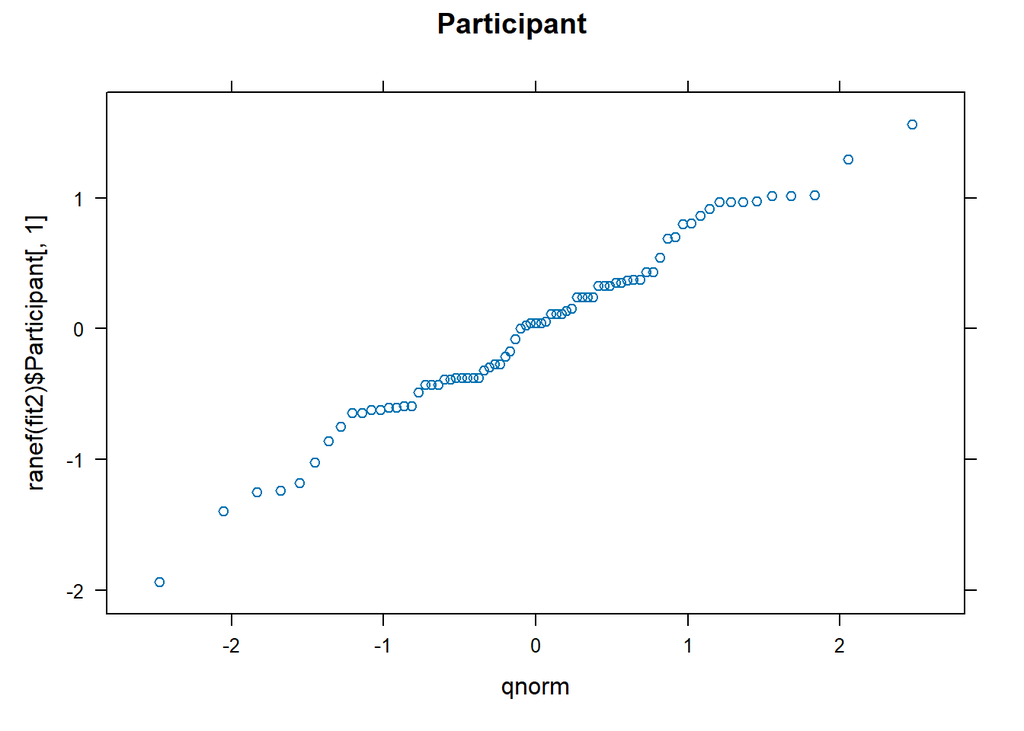

```r
qqmath(ranef(fit2)$Participant[,1], main="Participant")
```

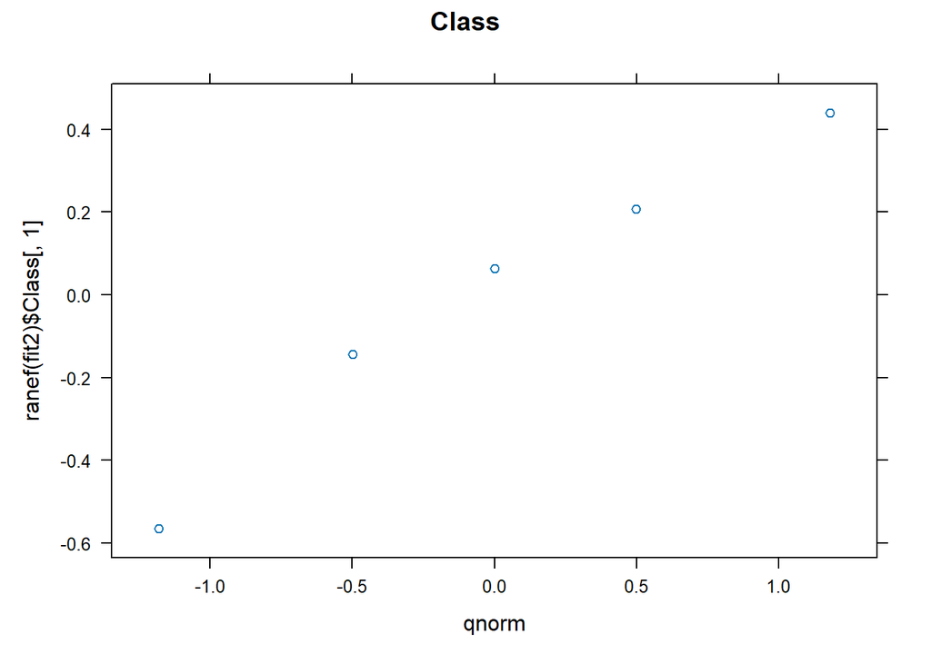

```r
qqmath(ranef(fit2)$Class[,1], main="Class")
```

Maybe some simulation to conclude whether the plots looks like they should.

## 8.

In order to examine how discretization of the response affects the LMM-based estimator for $\delta$, we simulate from the fit2 model, discretize the simulations by using the `round` function, fit a model on the simulated discretized data and extract the estimates and the CI boundaries.

```r
deltasim4 <- matrix(NA,M,3)

for (i in 1:M){
  y <- simulate(fit2)$sim_1 |> round() # evt. put alle forudsigelser større end 7 til 7, er det derfor vi har problemer i mange simulationer?????
  lmm2 <- lmer(y ~ ProdVersion + ProdType + (1|Participant) + (1|Class), data=likingdata)
  deltasim4[i,1] <- fixef(lmm2)[4]
  deltasim4[i,2:3] <- (lmm2 |> confint(method="Wald"))[7,]
}

deltasim4 <- deltasim4 |> data.frame()
names(deltasim4) <- c("est","lower","upper")
```

We calculate the bias:

```r
mean(deltasim4$est - fixef(fit2)[4]) |> knitr::kable(col.names = " ")
```

| -0.0004756 |
| --- |

And coverage:

```r
mean(deltasim4$lower <= fixef(fit2)[4] & fixef(fit2)[4] <= deltasim4$upper) |> knitr::kable(col.names = " ")
```

| 0.949 |
| --- |

We furthermore make a histogram over the estimated values

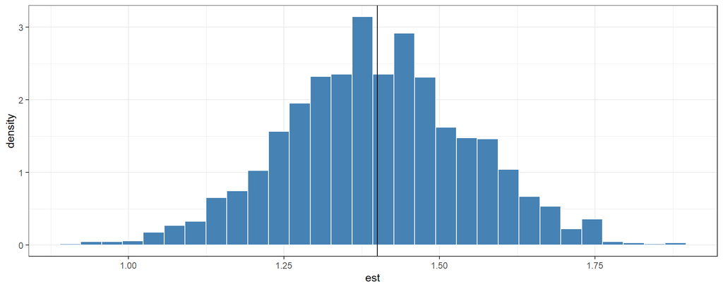

We still obtain unbiased estimates and accurate coverage. The distribution looks approximately normal as well…